# Trabalho — Laboratório de dados

## Apresentação dos datasets

Os microdados do ENEM de 2023 são observações individuáis de cada participante da prova do ENEM. Ao todo são 76 variáveis de 3.933.955 candidatos.

Abaixo há o link para um arquivo xlsx disponibilizado pelo INEP explicando cada uma das variáveis e seus valores admitidos. Mesmo assim, explicaremos as variáveis analizadas em nosso código e os valores que elas assumem.

A fonte, os dados e o dicionário explicando cada variável estão disponiveis, espectivamente, em:

Fonte: https://www.gov.br/inep/pt-br/acesso-a-informacao/dados-abertos/microdados/enem

Link para download: https://download.inep.gov.br/microdados/microdados_enem_2023.zip

Link alternativo dos dados: https://drive.google.com/file/d/11tXYljjw7HBLfk1-CkFPvcoCmrSaung4/view?usp=sharing

Link altenativo para o Dicionário: https://drive.google.com/file/d/1B-EaheHr1q30oYaxM-qpjxOwEVBgrIls/view?usp=sharing

Link para o Drive: https://drive.google.com/drive/folders/1DnubvVRmk_5iFwsrIi0mDBxtlEpTll-y?usp=drive_link

OBS: Pode ser necessário criar uma pasta cópia em /My Drive para reconhecer o caminho.

## Carregamento e tratamento

Como os dados estão disponibilizados apenas em csv, abrimos os dados pelo pandas e exportamos utilizando df.to_feather. Assim podemos carregar os dados mais rapidamente em memória.

```python
import seaborn as sns
import matplotlib.pyplot as plt
from scipy.stats import norm
import numpy as np
import geopandas as gpd
```

```python
import pandas as pd
from google.colab import drive
drive.mount('/content/drive')

df = pd.read_feather('/content/drive/My Drive/Trabalho de computação/MICRODADOS_ENEM_2023.feather')

##Demorou, no google colab, cerca de 45s para carregar em memória os dados.
```

## Testes de coerência

### Condição 1.1

Espera-se que o candidato que não compareceu à prova não possua nota.

A presença na prova X de um candidato é explicada na coluna 'TP_PRESENCA_X', onde X assume valores {'CN','MT','LC','CH'};

A coluna assume valores (int) 0, 1 ou 2, sendo: 0 = Ausente; 1 = Presente; 2 = Eliminado.

A nota do candidato em uma matéria é definida por 'NU_NOTA_X' (float64)

O candidato com 'TP_PRESENCA_X' deve possuir 'NU_NOTA_X' igual a 0:

```python
df.loc[(df['TP_PRESENCA_CN'] == 0) | (df['TP_PRESENCA_CN'] == 2), 'NU_NOTA_CN'] # Seleção bolleana para 'TP_PRESENCA_CN' == 0,2
```

|  | NU_NOTA_CN |
| --- | --- |
| 0 | NaN |
| 1 | NaN |
| 5 | NaN |
| 6 | NaN |
| 7 | NaN |
| ... | ... |
| 3933941 | NaN |
| 3933947 | NaN |
| 3933949 | NaN |
| 3933952 | NaN |
| 3933954 | NaN |

1241528 rows × 1 columns

**dtype:** float64

Perceba que, ao todo, 1.239.316 inscritos faltaram à prova de CN

Para todo X & Conferindo os valores não nulos:

```python
print(df.loc[((df['TP_PRESENCA_CN'] == 0) | (df['TP_PRESENCA_CN'] == 2) )& (df['NU_NOTA_CN'].notnull()), 'NU_NOTA_CN'],'\n',
      df.loc[((df['TP_PRESENCA_MT'] == 0) | (df['TP_PRESENCA_MT'] == 2) )& (df['NU_NOTA_MT'].notnull()), 'NU_NOTA_MT'],'\n',
      df.loc[((df['TP_PRESENCA_LC'] == 0) | (df['TP_PRESENCA_LC'] == 2) )& (df['NU_NOTA_LC'].notnull()), 'NU_NOTA_LC'],'\n',
      df.loc[((df['TP_PRESENCA_CH'] == 0) | (df['TP_PRESENCA_CH'] == 2) )& (df['NU_NOTA_CH'].notnull()), 'NU_NOTA_CH'])
```

```
Series([], Name: NU_NOTA_CN, dtype: float64)
 Series([], Name: NU_NOTA_MT, dtype: float64)
 Series([], Name: NU_NOTA_LC, dtype: float64)
 Series([], Name: NU_NOTA_CH, dtype: float64)
```

Series vazias indicam que não há um candidato que faltou e que não possua nota NaN

### Condição 1.2

Espera-se que o candidato que tenha faltado à prova de linguagens e códigos(LC) também tenha faltado à prova de ciências humanas(CH) e tenha sua redação zerada. Assim como o candidato que tenha faltado a prova de matemática(MT) também tenha faltado a prova de ciências naturais(CN).

```python
df.loc[(df['TP_PRESENCA_CN'] == 0) & (df['TP_PRESENCA_MT'] == 1) |
             (df['TP_PRESENCA_MT'] == 0) & (df['TP_PRESENCA_CN'] == 1) |
             (df['TP_PRESENCA_LC'] == 0) & (df['TP_PRESENCA_CH'] == 1) |
             (df['TP_PRESENCA_LC'] == 0) & (df['NU_NOTA_REDACAO'] == 1)|
             (df['TP_PRESENCA_CH'] == 0) & (df['NU_NOTA_REDACAO'] == 1)|
             (df['TP_PRESENCA_CH'] == 0) & (df['TP_PRESENCA_LC'] == 1),
             ['NU_NOTA_CN','NU_NOTA_LC','NU_NOTA_CH','NU_NOTA_MT','NU_NOTA_REDACAO']]
```

|  | NU_NOTA_CN | NU_NOTA_LC | NU_NOTA_CH | NU_NOTA_MT | NU_NOTA_REDACAO |
| --- | --- | --- | --- | --- | --- |

### Condição 2

Espera-se que o candidato que tenha sua redação em status Anulada, Cópia Texto Motivador, Em Branco, Fuga ao tema, Não atendimento ao tipo textual, Texto insuficiente ou Parte desconectada tenha sua redação zerada. A coluna que representa o status da redação é 'TP_STATUS_REDACAO', que assume valores (int) de 1 a 9, onde os valores diferentes de 1 representam, respectivamente, as condições acima e um indica 'sem problemas'.

Dessa forma, o candidato que possuir 'TP_STATUS_REDACAO' diferente de 1 deve ter sua redação zerada:

```python
df.loc[
    (df['TP_STATUS_REDACAO'] != 1) &
    (df['NU_NOTA_REDACAO'].notnull()) &
    (df['NU_NOTA_REDACAO'] != 0),
    ['TP_STATUS_REDACAO', 'NU_NOTA_REDACAO']
]
```

|  | TP_STATUS_REDACAO | NU_NOTA_REDACAO |
| --- | --- | --- |

### Condição 3

Espera-se que a nota da prova de redação seja a soma das notas em cada uma das competências.

Criamos a coluna 'Soma_Redacao'

```python
df['Soma_Redacao'] = df['NU_NOTA_COMP1']+df['NU_NOTA_COMP2'] + df['NU_NOTA_COMP3'] + df['NU_NOTA_COMP4'] + df['NU_NOTA_COMP5']
df.loc[(df['NU_NOTA_REDACAO'] != df['Soma_Redacao']) & (df['NU_NOTA_REDACAO'].notnull()), ['NU_NOTA_REDACAO','Soma_Redacao', 'NU_NOTA_COMP1', 'NU_NOTA_COMP2', 'NU_NOTA_COMP3', 'NU_NOTA_COMP4', 'NU_NOTA_COMP5']]
```

|  | NU_NOTA_REDACAO | Soma_Redacao | NU_NOTA_COMP1 | NU_NOTA_COMP2 | NU_NOTA_COMP3 | NU_NOTA_COMP4 | NU_NOTA_COMP5 |
| --- | --- | --- | --- | --- | --- | --- | --- |
| 289834 | 320.0 | 290.0 | 80.0 | 40.0 | 10.0 | 120.0 | 40.0 |

Há apenas aluno no qual sua nota da redação não é a soma das notas de suas competências. Esse é um erro na base de dados.

## Condição 4

Espera-se que o candidato que esteja na faixa de renda('Q006") I:Q(acima de 6.600,01 reais por mês) tenha banheiro em sua casa ('Q008'). Parece bobo, mas é um indicador do grau de mentira associado à resposta geral dos candidatos.

```python
df.loc[(df['Q008'] == 'A'),['Q008','Q006']].groupby('Q006').count().sort_values(by='Q006')
```

| Q006 | Q008 |
| --- | --- |
| A | 15066 |
| B | 18798 |
| C | 2223 |
| D | 813 |
| E | 387 |
| F | 167 |
| G | 175 |
| H | 88 |
| I | 36 |
| J | 35 |
| K | 16 |
| L | 14 |
| M | 7 |
| N | 14 |
| O | 10 |
| P | 4 |
| Q | 25 |

Isso indica que 15066 candidatos que marcaram a opção "não possuo renda" moram em uma residencia que não possui banheiro, e assim por diante...

Julgar a veracidade dos números pode ser necessário. Entretanto, não são números significantes comparados ao tamanho da base de dados.

```python
inconsistencias_lc_ch = df.loc[(df['TP_PRESENCA_LC'] == 0) & (df['TP_PRESENCA_CH'] == 1) & (df['NU_NOTA_LC'].notnull()),['NU_NOTA_LC', 'TP_PRESENCA_LC', 'TP_PRESENCA_CH']]
inconsistencias_mt_cn = df.loc[(df['TP_PRESENCA_MT'] == 0) & (df['TP_PRESENCA_CN'] == 1) & (df['NU_NOTA_LC'].notnull()),['NU_NOTA_LC', 'TP_PRESENCA_MT', 'TP_PRESENCA_CN']]
inconsistencias_lc_redacao = df.loc[(df['TP_PRESENCA_LC'] == 0) & (df['NU_NOTA_REDACAO'].notnull()) & (df['NU_NOTA_REDACAO'] != 0),['NU_NOTA_REDACAO', 'TP_PRESENCA_LC']]
inconsistencias_ch_redacao = df.loc[(df['TP_PRESENCA_CH'] == 0) & (df['NU_NOTA_REDACAO'].notnull()) & (df['NU_NOTA_REDACAO'] != 0),['NU_NOTA_REDACAO', 'TP_PRESENCA_CH']]

inconsistencia = pd.concat([inconsistencias_lc_ch, inconsistencias_mt_cn, inconsistencias_lc_redacao, inconsistencias_ch_redacao])
inconsistencia
```

|  | NU_NOTA_LC | TP_PRESENCA_LC | TP_PRESENCA_CH | TP_PRESENCA_MT | TP_PRESENCA_CN | NU_NOTA_REDACAO |
| --- | --- | --- | --- | --- | --- | --- |

## Descrição estatística do dataset

Apresente estatísticas básicas sobre o seu dataset (médias, medianas, variância, etc.). Faça também uma análise dos dados atípicos (*outliers*) do dataset. Por que você acha que esses dados são atípicos? Você acha que são erros de medida, casos extraordinários, …?

```python
df['Media_Notas'] = df[['NU_NOTA_MT', 'NU_NOTA_CN', 'NU_NOTA_CH', 'NU_NOTA_LC', 'NU_NOTA_REDACAO']].mean(axis=1)
```

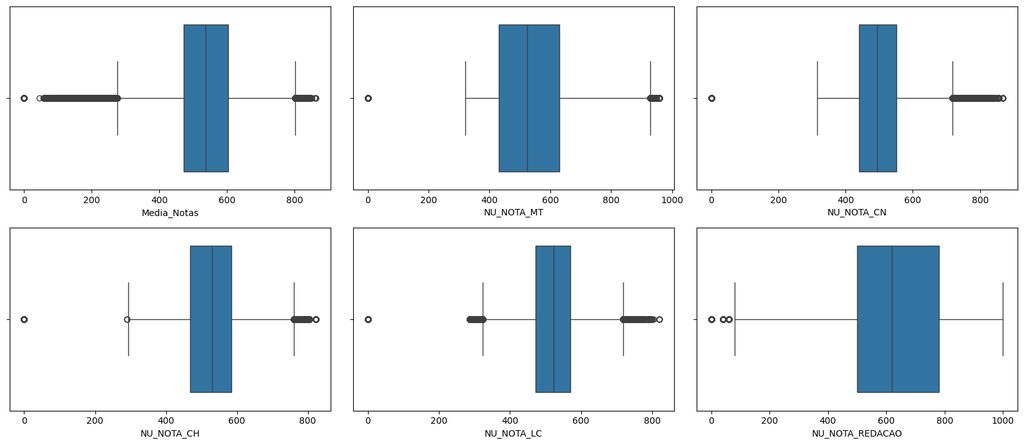

```python
mediana_notas = df['Media_Notas'].median()
variancia_notas = df['Media_Notas'].var()
moda_todas_notas = df[['NU_NOTA_MT', 'NU_NOTA_CN', 'NU_NOTA_CH', 'NU_NOTA_LC', 'NU_NOTA_REDACAO']].mode()
moda_nota_mt = df['NU_NOTA_MT'].mode()
moda_nota_cn = df['NU_NOTA_CN'].mode()
moda_nota_ch = df['NU_NOTA_CH'].mode()
moda_nota_lc = df['NU_NOTA_LC'].mode()
moda_nota_redacao = df['NU_NOTA_REDACAO'].mode()
desvio_padrao = df[['NU_NOTA_MT', 'NU_NOTA_CN', 'NU_NOTA_CH', 'NU_NOTA_LC', 'NU_NOTA_REDACAO']].std()


fig1, axes1 = plt.subplots(nrows=2, ncols=3, figsize=(16, 7))

sns.boxplot(x=df['Media_Notas'],ax=axes1[0,0])

sns.boxplot(x=df['NU_NOTA_MT'],ax=axes1[0,1])

sns.boxplot(x=df['NU_NOTA_CN'],ax=axes1[0,2])

sns.boxplot(x=df['NU_NOTA_CH'],ax=axes1[1,0])

sns.boxplot(x=df['NU_NOTA_LC'],ax=axes1[1,1])

sns.boxplot(x=df['NU_NOTA_REDACAO'],ax=axes1[1,2])

plt.tight_layout()
plt.show()
```

#### Outliers

```python
print(df.loc[df['Media_Notas']>df['Media_Notas'].quantile(.99999)]["Media_Notas"].sort_values().tail(),
      df.loc[(df['Media_Notas']<df['Media_Notas'].quantile(0.000475)) & (df['Media_Notas']!=0)]["Media_Notas"].sort_values().head())
```

```
842422     850.40
391420     858.65
3638151    860.75
3405360    862.50
1818773    862.58
Name: Media_Notas, dtype: float64 2601121    44.00
1415510    56.00
2635553    57.44
3879229    57.54
1349836    57.62
Name: Media_Notas, dtype: float64
```

Essas são as notas dos melhores e dos piores candidatos - com exceção alunos dos que ficaram com 0

#### Comportamento

Os dados se comportam de acordo com uma distribuição normal de média 536 e desvio padrão de 98

```python
df1 = df['Media_Notas'].loc[(df['Media_Notas'].notnull())]

df2 = pd.cut(df1, bins=range(0,1010,10)).value_counts().sort_index()

med_std = df1.mean(),df1.std()
med_std
```

```
(536.6048780294924, 98.08076112841732)
```

Procuramos também nossas observações no dataset

```python
df.iloc[[df.loc[(df['NU_NOTA_LC'] == 583.2) & (df['NU_NOTA_MT'] == 823.1)]["Media_Notas"].index.tolist()[0],
      df.loc[(df['NU_NOTA_MT'] == 893.7) & (df['NU_NOTA_REDACAO'] == 920) & (df['NU_NOTA_LC'] == 632.7)]['Media_Notas'].index.tolist()[0]]]
```

|  | NU_INSCRICAO | NU_ANO | TP_FAIXA_ETARIA | TP_SEXO | TP_ESTADO_CIVIL | TP_COR_RACA | TP_NACIONALIDADE | TP_ST_CONCLUSAO | TP_ANO_CONCLUIU | TP_ESCOLA | ... | Q018 | Q019 | Q020 | Q021 | Q022 | Q023 | Q024 | Q025 | Soma_Redacao | Media_Notas |
| --- | --- | --- | --- | --- | --- | --- | --- | --- | --- | --- | --- | --- | --- | --- | --- | --- | --- | --- | --- | --- | --- |
| 612876 | 210059450108 | 2023 | 4 | M | 1 | 1 | 1 | 2 | 0 | 2 | ... | B | E | B | B | E | B | B | B | 940.0 | 708.72 |
| 2241568 | 210058102502 | 2023 | 2 | M | 1 | 1 | 1 | 2 | 0 | 2 | ... | A | B | A | A | D | A | B | B | 920.0 | 763.82 |

2 rows × 78 columns

# Perguntas

Qual a distribuição de notas no ENEM?

Qual é o impacto do nível de renda na nota das alunos? Essa diferença é relevante?

Qual a proporção de cada intervalo de renda no numero total de participantes?

O sexo do aluno afeta seu rendimento de maneira geral? Como isso ocorre?

Em quais materias os homens vão melhor e pior que as mulheres?

Como a posse de eletrodomésticos, internet... Afeta o rendimento do aluno?

Qual o impacto de escolas privadas na nota do ENEM?

Existem escolas publicas que se igualem a escolas privadas?

Como o nivel de gestão da escola afeta o rendimento dos alunos?

```python
## Plots da distribuição das notas
df3 = pd.DataFrame(norm.pdf(range(0,1000,10),loc=536.6048780294924, scale=98.08076112841732))
df3.set_index(df2.index)
df3 = df3*115854/0.004065 ## Transformar o valor da densidade de probabilidade (Elemento de 0 a 1) no número de contagens observados em cada intervalo
df3.rename(columns={0:'Densidade da Normal'}, inplace=True)
df2.rename('Número de Alunos', inplace=True)

## Plots da média com Q006
df4 = df[['Media_Notas','Q006']].groupby('Q006').mean()

df5= df.groupby('Q006').size().reset_index(name='Contagem')
df5.columns = ['Resposta', 'Contagem']
df5.set_index('Resposta', inplace=True)
```

```python
df['Notas_Sem_Redacao'] = df[['NU_NOTA_MT', 'NU_NOTA_CN', 'NU_NOTA_CH', 'NU_NOTA_LC']].mean(axis=1)
df6 = df[['TP_SEXO',"Media_Notas",'Notas_Sem_Redacao','NU_NOTA_REDACAO',
          'NU_NOTA_MT','NU_NOTA_CN']].groupby('TP_SEXO').mean().rename({'M':'Masculino','F':'Feminino'}).rename(columns={
              'Media_Notas':'Total','Notas_Sem_Redacao':'s/ Redação',
              'NU_NOTA_REDACAO':'Redação','NU_NOTA_MT':'Matemática','NU_NOTA_CN':'Natureza'}).transpose().sort_values(by='Feminino',ascending=False)
```

```python
df7 = pd.DataFrame([df['Media_Notas'].loc[df['Q014']=='A'].mean(),df['Media_Notas'].loc[df['Q014']!='A'].mean(

)]).rename({0:'Não',1:'Sim'}).rename(columns={0:'Pos Máq Lavar?'})

df8 = df['Media_Notas'].groupby(df['Q025']).mean().rename({'A':'Não','B':'Sim'}).rename('Pos Internet?')

df9 = pd.DataFrame([df['Media_Notas'].loc[df['Q012']=='A'].mean(),df['Media_Notas'].loc[df['Q012']!='A'].mean(

)]).rename({0:'Não',1:'Sim'}).rename(columns={0:'Pos Geladeira?'})

df10 = pd.DataFrame([df['Media_Notas'].loc[df['Q010']=='A'].mean(),df['Media_Notas'].loc[df['Q012']!='A'].mean(

)]).rename({0:'Não',1:'Sim'}).rename(columns={0:'Pos Carro?'})

df7=df7.join(df8).join(df9).join(df10).transpose()

df['Tipo_Escola'] = df['TP_DEPENDENCIA_ADM_ESC'].map({1: 'Federal',2: 'Estadual', 3: 'Municial', 4: 'Privada'})
```

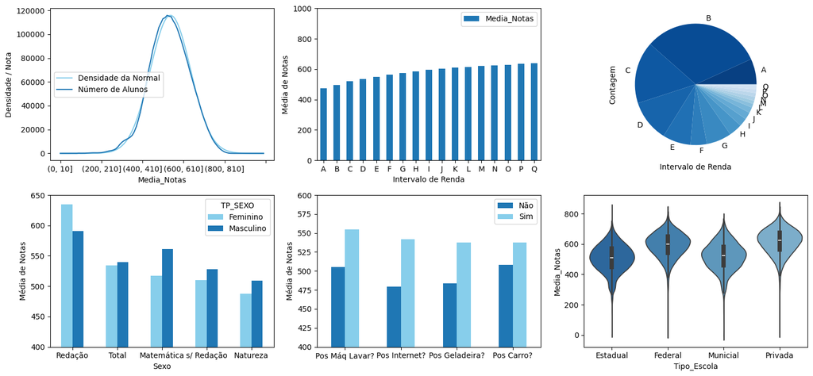

```python
## Ajustes do plot
fig, axes = plt.subplots(nrows=2, ncols=3, figsize=(15, 7))


df3.plot(color='skyblue',ax=axes[0,0],ylabel=('Densidade / Nota'),xlabel=('Intervalo de Renda'))
df2.plot(ax=axes[0,0],subplots=True,legend=True)


df4.plot(kind='bar',ax=axes[0,1],ylim = (0,1000),rot=0,ylabel= ('Média de Notas'),xlabel=('Intervalo de Renda'), legend=True,color='#1f77b4')

df5.plot(kind = 'pie',y='Contagem',ax=axes[0,2], colors=plt.cm.Blues(range(240, 0, -12)),legend=False)
axes[0,2].set_xlabel('Intervalo de Renda')

df6.plot(kind='bar',ax=axes[1,0],ylabel= ('Média de Notas'),rot=0, legend=True,ylim=(400,650),color=['skyblue','#1f77b4'])

df7.plot(kind='bar',ax=axes[1,1],ylabel= ('Média de Notas'),rot=0, legend=True,ylim=(400,600),color=['#1f77b4','skyblue'])

sns.violinplot(
    x='Tipo_Escola',
    y='Media_Notas',
    data=df,
    hue='Tipo_Escola',  # Colorir por categoria
    palette=plt.cm.Blues(range(200, 100, -25)).tolist(),
    legend=False,
    ax=axes[1, 2])

plt.tight_layout()
plt.show()
```

Para responder essas perguntas, podemos nos embasar nos gráficos acima.

A nota do ENEM é padronizada para a média de 2009 ser 500. Com isso em mente, percebe-se que houve um aumento da capacidade média dos alunos em realizar a prova desde 2009, mas infelizmente um aumento marginal.

A renda afeta a nota de maneira estritamente crescente - o que é contraintuitivo - já que é plausivel pensar que conforme a renda assume intervalos muito grandes (acima de 26 mil reais por mês) pode haver um incertivo ao aluno não se dedicar tanto - o que não é verdade, com base no gráfico.

As mulheres vão relativamente melhor em matérias de humanas e redação e os homens vão relativamente melhor em matérias exatas, o que é interessante do ponto de vista cultural.

Possuir ou não tais coisas é claramente uma variável com alto grau de dependencia na renda. A ideia desse gráfico era comparar especificadamente o impácto de acesso a internet no resultado da prova, mas não há um impácto significativamente maior do que a posse de maquina de lavar e geladeira.

As escolas de nível federal conseguem manter um nível bastante parecido com de instituições privadas, talvez essa seja uma evidência da eficiencia desse tipo de instituição, mas como elas possuem prova de seleção para o ingresso, esse pode ser apenas um viés de taxa base.

```python
# Dicionário de regiões
regioes = {
    'Norte': ['AC', 'AP', 'AM', 'PA', 'RO', 'RR', 'TO'],
    'Nordeste': ['AL', 'BA', 'CE', 'MA', 'PB', 'PE', 'PI', 'RN', 'SE'],
    'Centro-Oeste': ['DF', 'GO', 'MT', 'MS'],
    'Sudeste': ['ES', 'MG', 'RJ', 'SP'],
    'Sul': ['PR', 'RS', 'SC']
}

# Função para obter a região
def get_regiao(estado):
    for regiao, estados in regioes.items():
        if estado in estados:
            return regiao
    return None

# Supondo df seja seu DataFrame de notas
df['Regiao'] = df['SG_UF_PROVA'].apply(get_regiao)

# Média por região
media_por_regiao = df.groupby('Regiao')['Media_Notas'].mean().reset_index()

# Shapefile do Brasil (ajustar para obter localmente ou via URL)
url_shapefile = 'https://biogeo.ucdavis.edu/data/gadm3.6/shp/gadm36_BRA_shp.zip'
brasil = gpd.read_file(url_shapefile, layer='gadm36_BRA_1')  # Ajuste o nível conforme necessário

# Filtrando apenas as regiões do Brasil
brasil = brasil[['NAME_1', 'geometry']].rename(columns={'NAME_1': 'Estado'})

# Plotando a média das notas por região
plt.figure(figsize=(10, 6))
plt.bar(media_por_regiao['Regiao'], media_por_regiao['Media_Notas'], color='skyblue')
plt.title('Média de Notas por Região do Brasil')
plt.xlabel('Região')
plt.ylabel('Média de Notas')
plt.xticks(rotation=45)
plt.show()
```

[output not shown]

[output cut: 59 more lines]

[output not shown]